# MSCA 31015 Final Assignment

```python
import numpy as np
import pandas as pd

pd.set_option('display.max_columns', 100)
pd.set_option('display.max_rows', 900)
```

```python
df = pd.read_excel('Final Assignment - Week 9.xlsx')
```

```python
book.dtypes
```

```
id                    int64
logtarg             float64
r                     int64
f                     int64
m                   float64
tof                   int64
Ffiction1             int64
Fclassics3            int64
Fcartoons5            int64
Flegends6             int64
Fphilosophy7          int64
Freligion8            int64
Fpsychology9          int64
Flinguistics10        int64
Fart12                int64
Fmusic14              int64
Ffacsimile17          int64
Fhistory19            int64
Fconthist20           int64
Feconomy21            int64
Fpolitics22           int64
Fscience23            int64
Fcompsci26            int64
Frailroads27          int64
Fmaps30               int64
Ftravelguides31       int64
Fhealth35             int64
Fcooking36            int64
Flearning37           int64
FGamesRiddles38       int64
Fsports39             int64
Fhobby40              int64
Fnature41             int64
Fencyclopaedia44      int64
Fvideos50             int64
Fnonbooks99           int64
Mfiction1           float64
Mclassics3          float64
Mcartoons5          float64
Mlegends6           float64
```

[output cut: 15 more lines]

```
Mtravelguides31     float64
Mhealth35           float64
Mcooking36          float64
Mlearning37         float64
MGamesRiddles38     float64
Msports39           float64
Mhobby40            float64
Mnature41           float64
Mencyclopaedia44    float64
Mvideos50           float64
Mnonbooks99         float64
Unnamed: 66         float64
Unnamed: 67         float64
Dear Greg,           object
dtype: object
```

### 1. Perform descriptive statistics on all variables to help understand the data, the distributions and basic info you have to work with on this challenge. (Mean, Standard Deviation, Median, Min, Max and Histogram)

```python
df.head()
```

|  | id | logtarg | r | f | m | tof | Ffiction1 | Fclassics3 | Fcartoons5 | Flegends6 | Fphilosophy7 | Freligion8 | Fpsychology9 | Flinguistics10 | Fart12 | Fmusic14 | Ffacsimile17 | Fhistory19 | Fconthist20 | Feconomy21 | Fpolitics22 | Fscience23 | Fcompsci26 | Frailroads27 | Fmaps30 | Ftravelguides31 | Fhealth35 | Fcooking36 | Flearning37 | … |
| --- | --- | --- | --- | --- | --- | --- | --- | --- | --- | --- | --- | --- | --- | --- | --- | --- | --- | --- | --- | --- | --- | --- | --- | --- | --- | --- | --- | --- | --- | --- |
| 0 | 914 | NaN | 194 | 7 | 318.894775 | 1703 | 1 | 0 | 1 | 0 | 0 | 0 | 0 | 0 | 1 | 7 | 0 | 0 | 17 | 0 | 0 | 0 | 0 | 0 | 0 | 2 | 2 | 1 | 0 | … |
| 1 | 957 | NaN | 3 | 14 | 368.052246 | 2364 | 1 | 0 | 2 | 0 | 0 | 0 | 0 | 0 | 0 | 4 | 0 | 4 | 4 | 0 | 0 | 0 | 1 | 0 | 0 | 0 | 7 | 0 | 4 | … |
| 2 | 1406 | NaN | 1489 | 15 | 423.298340 | 2371 | 0 | 0 | 0 | 0 | 0 | 0 | 0 | 0 | 0 | 0 | 0 | 1 | 34 | 0 | 0 | 0 | 0 | 0 | 0 | 0 | 0 | 0 | 0 | … |
| 3 | 1414 | NaN | 155 | 4 | 71.217041 | 1290 | 0 | 0 | 0 | 0 | 0 | 0 | 0 | 0 | 0 | 0 | 0 | 0 | 7 | 0 | 0 | 0 | 0 | 0 | 0 | 0 | 0 | 0 | 0 | … |
| 4 | 1546 | NaN | 194 | 6 | 442.638184 | 2188 | 0 | 0 | 1 | 0 | 3 | 1 | 0 | 1 | 1 | 3 | 0 | 6 | 7 | 1 | 0 | 2 | 0 | 2 | 0 | 1 | 3 | 0 | 2 | … |

```python
df.info()
```

```
<class 'pandas.core.frame.DataFrame'>
RangeIndex: 33713 entries, 0 to 33712
Data columns (total 69 columns):
 #   Column            Non-Null Count  Dtype
---  ------            --------------  -----
 0   id                33713 non-null  int64
 1   logtarg           8311 non-null   float64
 2   r                 33713 non-null  int64
 3   f                 33713 non-null  int64
 4   m                 33713 non-null  float64
 5   tof               33713 non-null  int64
 6   Ffiction1         33713 non-null  int64
 7   Fclassics3        33713 non-null  int64
 8   Fcartoons5        33713 non-null  int64
 9   Flegends6         33713 non-null  int64
```

[output cut: 61 more lines]

```python
df.describe()
```

|  | id | logtarg | r | f | m | tof | Ffiction1 | Fclassics3 | Fcartoons5 | Flegends6 | Fphilosophy7 | Freligion8 | Fpsychology9 | Flinguistics10 | Fart12 | Fmusic14 | Ffacsimile17 | Fhistory19 | Fconthist20 | Feconomy21 | Fpolitics22 | Fscience23 | Fcompsci26 | Frailroads27 | Fmaps30 | Ftravelguides31 | Fhealth35 | Fcooking36 | Flearning37 | … |
| --- | --- | --- | --- | --- | --- | --- | --- | --- | --- | --- | --- | --- | --- | --- | --- | --- | --- | --- | --- | --- | --- | --- | --- | --- | --- | --- | --- | --- | --- | --- |
| count | 3.371300e+04 | 8311.000000 | 33713.000000 | 33713.000000 | 33713.000000 | 33713.000000 | 33713.000000 | 33713.000000 | 33713.000000 | 33713.000000 | 33713.000000 | 33713.000000 | 33713.000000 | 33713.000000 | 33713.000000 | 33713.000000 | 33713.000000 | 33713.000000 | 33713.000000 | 33713.000000 | 33713.000000 | 33713.000000 | 33713.000000 | 33713.000000 | 33713.000000 | 33713.000000 | 33713.000000 | 33713.000000 | 33713.00000 | … |
| mean | 8.234209e+06 | 0.130050 | 508.427254 | 5.820603 | 251.924325 | 1296.088186 | 0.590900 | 0.228102 | 0.356480 | 0.104767 | 0.290659 | 0.980957 | 0.046570 | 0.203215 | 0.608549 | 2.320974 | 0.050960 | 2.647940 | 2.153947 | 0.208377 | 0.029959 | 0.410791 | 0.150862 | 0.187020 | 0.074986 | 1.484976 | 2.109898 | 0.425444 | 0.61718 | … |
| std | 4.426015e+06 | 0.659962 | 542.440039 | 7.008049 | 3929.929826 | 818.976321 | 1.762201 | 0.865510 | 1.105653 | 0.527764 | 1.088606 | 3.112212 | 0.262156 | 0.641489 | 1.884077 | 6.681362 | 0.398608 | 5.930653 | 5.989002 | 0.755520 | 0.190992 | 1.480713 | 0.596788 | 0.974306 | 0.335845 | 4.368954 | 5.340294 | 1.695695 | 1.64184 | … |
| min | 9.140000e+02 | 0.000000 | 0.000000 | 0.000000 | 0.000000 | 0.000000 | 0.000000 | 0.000000 | 0.000000 | 0.000000 | 0.000000 | 0.000000 | 0.000000 | 0.000000 | 0.000000 | 0.000000 | 0.000000 | 0.000000 | 0.000000 | 0.000000 | 0.000000 | 0.000000 | 0.000000 | 0.000000 | 0.000000 | 0.000000 | 0.000000 | 0.000000 | 0.00000 | … |
| 25% | 4.391616e+06 | 0.000000 | 117.000000 | 1.000000 | 39.899994 | 536.000000 | 0.000000 | 0.000000 | 0.000000 | 0.000000 | 0.000000 | 0.000000 | 0.000000 | 0.000000 | 0.000000 | 0.000000 | 0.000000 | 0.000000 | 0.000000 | 0.000000 | 0.000000 | 0.000000 | 0.000000 | 0.000000 | 0.000000 | 0.000000 | 0.000000 | 0.000000 | 0.00000 | … |
| 50% | 7.967691e+06 | 0.000000 | 293.000000 | 3.000000 | 102.629944 | 1311.000000 | 0.000000 | 0.000000 | 0.000000 | 0.000000 | 0.000000 | 0.000000 | 0.000000 | 0.000000 | 0.000000 | 0.000000 | 0.000000 | 1.000000 | 0.000000 | 0.000000 | 0.000000 | 0.000000 | 0.000000 | 0.000000 | 0.000000 | 0.000000 | 0.000000 | 0.000000 | 0.00000 | … |
| 75% | 1.199823e+07 | 0.000000 | 712.000000 | 7.000000 | 247.297485 | 2132.000000 | 1.000000 | 0.000000 | 0.000000 | 0.000000 | 0.000000 | 1.000000 | 0.000000 | 0.000000 | 1.000000 | 2.000000 | 0.000000 | 3.000000 | 2.000000 | 0.000000 | 0.000000 | 0.000000 | 0.000000 | 0.000000 | 0.000000 | 1.000000 | 2.000000 | 0.000000 | 1.00000 | … |
| max | 1.625264e+07 | 6.082878 | 2460.000000 | 118.000000 | 532892.000000 | 2462.000000 | 109.000000 | 29.000000 | 49.000000 | 22.000000 | 35.000000 | 134.000000 | 8.000000 | 21.000000 | 113.000000 | 264.000000 | 23.000000 | 192.000000 | 213.000000 | 18.000000 | 6.000000 | 55.000000 | 17.000000 | 61.000000 | 10.000000 | 164.000000 | 210.000000 | 78.000000 | 59.00000 | … |

```python
df.isnull().sum(axis=0)
```

```
id                      0
logtarg             25402
r                       0
f                       0
m                       0
tof                     0
Ffiction1               0
Fclassics3              0
Fcartoons5              0
Flegends6               0
Fphilosophy7            0
Freligion8              0
Fpsychology9            0
Flinguistics10          0
Fart12                  0
Fmusic14                0
Ffacsimile17            0
Fhistory19              0
Fconthist20             0
Feconomy21              0
Fpolitics22             0
Fscience23              0
Fcompsci26              0
Frailroads27            0
Fmaps30                 0
Ftravelguides31         0
Fhealth35               0
Fcooking36              0
Flearning37             0
FGamesRiddles38         0
Fsports39               0
Fhobby40                0
Fnature41               0
Fencyclopaedia44        0
Fvideos50               0
Fnonbooks99             0
Mfiction1               0
Mclassics3              0
Mcartoons5              0
Mlegends6               0
```

[output cut: 15 more lines]

```
Mtravelguides31         0
Mhealth35               0
Mcooking36              0
Mlearning37             0
MGamesRiddles38         0
Msports39               0
Mhobby40                0
Mnature41               0
Mencyclopaedia44        0
Mvideos50               0
Mnonbooks99             0
Unnamed: 66         33713
Unnamed: 67         33713
Dear Greg,          33709
dtype: int64
```

```python
df.shape
```

```
(33713, 69)
```

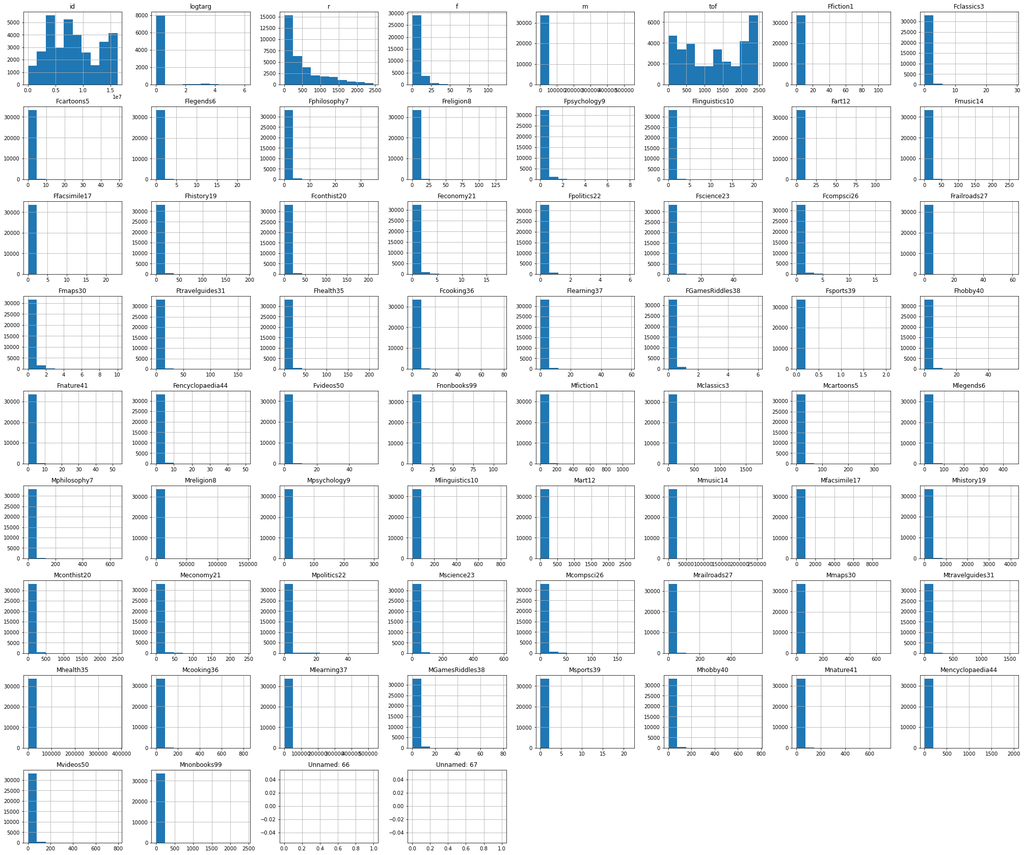

```python
import matplotlib.pyplot as plt
fig = plt.figure(figsize=(35,30));
ax = fig.gca()
df.hist(ax=ax)
pass
```

### 2. Create a new data set with more descriptive labels and the data needed for analysis

```python
df = df.drop(columns = ['Unnamed: 66','Unnamed: 67','Dear Greg,'])
```

```python
df.head()
```

|  | id | logtarg | r | f | m | tof | Ffiction1 | Fclassics3 | Fcartoons5 | Flegends6 | Fphilosophy7 | Freligion8 | Fpsychology9 | Flinguistics10 | Fart12 | Fmusic14 | Ffacsimile17 | Fhistory19 | Fconthist20 | Feconomy21 | Fpolitics22 | Fscience23 | Fcompsci26 | Frailroads27 | Fmaps30 | Ftravelguides31 | Fhealth35 | Fcooking36 | Flearning37 | … |
| --- | --- | --- | --- | --- | --- | --- | --- | --- | --- | --- | --- | --- | --- | --- | --- | --- | --- | --- | --- | --- | --- | --- | --- | --- | --- | --- | --- | --- | --- | --- |
| 0 | 914 | NaN | 194 | 7 | 318.894775 | 1703 | 1 | 0 | 1 | 0 | 0 | 0 | 0 | 0 | 1 | 7 | 0 | 0 | 17 | 0 | 0 | 0 | 0 | 0 | 0 | 2 | 2 | 1 | 0 | … |
| 1 | 957 | NaN | 3 | 14 | 368.052246 | 2364 | 1 | 0 | 2 | 0 | 0 | 0 | 0 | 0 | 0 | 4 | 0 | 4 | 4 | 0 | 0 | 0 | 1 | 0 | 0 | 0 | 7 | 0 | 4 | … |
| 2 | 1406 | NaN | 1489 | 15 | 423.298340 | 2371 | 0 | 0 | 0 | 0 | 0 | 0 | 0 | 0 | 0 | 0 | 0 | 1 | 34 | 0 | 0 | 0 | 0 | 0 | 0 | 0 | 0 | 0 | 0 | … |
| 3 | 1414 | NaN | 155 | 4 | 71.217041 | 1290 | 0 | 0 | 0 | 0 | 0 | 0 | 0 | 0 | 0 | 0 | 0 | 0 | 7 | 0 | 0 | 0 | 0 | 0 | 0 | 0 | 0 | 0 | 0 | … |
| 4 | 1546 | NaN | 194 | 6 | 442.638184 | 2188 | 0 | 0 | 1 | 0 | 3 | 1 | 0 | 1 | 1 | 3 | 0 | 6 | 7 | 1 | 0 | 2 | 0 | 2 | 0 | 1 | 3 | 0 | 2 | … |

```python
df.shape
```

```
(33713, 66)
```

```python
df.isnull().sum()
```

```
id                      0
logtarg             25402
r                       0
f                       0
m                       0
tof                     0
Ffiction1               0
Fclassics3              0
Fcartoons5              0
Flegends6               0
Fphilosophy7            0
Freligion8              0
Fpsychology9            0
Flinguistics10          0
Fart12                  0
Fmusic14                0
Ffacsimile17            0
Fhistory19              0
Fconthist20             0
Feconomy21              0
Fpolitics22             0
Fscience23              0
Fcompsci26              0
Frailroads27            0
Fmaps30                 0
Ftravelguides31         0
Fhealth35               0
Fcooking36              0
Flearning37             0
FGamesRiddles38         0
Fsports39               0
Fhobby40                0
Fnature41               0
Fencyclopaedia44        0
Fvideos50               0
Fnonbooks99             0
Mfiction1               0
Mclassics3              0
Mcartoons5              0
Mlegends6               0
```

[output cut: 12 more lines]

```
Mcompsci26              0
Mrailroads27            0
Mmaps30                 0
Mtravelguides31         0
Mhealth35               0
Mcooking36              0
Mlearning37             0
MGamesRiddles38         0
Msports39               0
Mhobby40                0
Mnature41               0
Mencyclopaedia44        0
Mvideos50               0
Mnonbooks99             0
dtype: int64
```

```python
df.describe()
```

|  | id | logtarg | r | f | m | tof | Ffiction1 | Fclassics3 | Fcartoons5 | Flegends6 | Fphilosophy7 | Freligion8 | Fpsychology9 | Flinguistics10 | Fart12 | Fmusic14 | Ffacsimile17 | Fhistory19 | Fconthist20 | Feconomy21 | Fpolitics22 | Fscience23 | Fcompsci26 | Frailroads27 | Fmaps30 | Ftravelguides31 | Fhealth35 | Fcooking36 | Flearning37 | … |
| --- | --- | --- | --- | --- | --- | --- | --- | --- | --- | --- | --- | --- | --- | --- | --- | --- | --- | --- | --- | --- | --- | --- | --- | --- | --- | --- | --- | --- | --- | --- |
| count | 3.371300e+04 | 8311.000000 | 33713.000000 | 33713.000000 | 33713.000000 | 33713.000000 | 33713.000000 | 33713.000000 | 33713.000000 | 33713.000000 | 33713.000000 | 33713.000000 | 33713.000000 | 33713.000000 | 33713.000000 | 33713.000000 | 33713.000000 | 33713.000000 | 33713.000000 | 33713.000000 | 33713.000000 | 33713.000000 | 33713.000000 | 33713.000000 | 33713.000000 | 33713.000000 | 33713.000000 | 33713.000000 | 33713.00000 | … |
| mean | 8.234209e+06 | 0.130050 | 508.427254 | 5.820603 | 251.924325 | 1296.088186 | 0.590900 | 0.228102 | 0.356480 | 0.104767 | 0.290659 | 0.980957 | 0.046570 | 0.203215 | 0.608549 | 2.320974 | 0.050960 | 2.647940 | 2.153947 | 0.208377 | 0.029959 | 0.410791 | 0.150862 | 0.187020 | 0.074986 | 1.484976 | 2.109898 | 0.425444 | 0.61718 | … |
| std | 4.426015e+06 | 0.659962 | 542.440039 | 7.008049 | 3929.929826 | 818.976321 | 1.762201 | 0.865510 | 1.105653 | 0.527764 | 1.088606 | 3.112212 | 0.262156 | 0.641489 | 1.884077 | 6.681362 | 0.398608 | 5.930653 | 5.989002 | 0.755520 | 0.190992 | 1.480713 | 0.596788 | 0.974306 | 0.335845 | 4.368954 | 5.340294 | 1.695695 | 1.64184 | … |
| min | 9.140000e+02 | 0.000000 | 0.000000 | 0.000000 | 0.000000 | 0.000000 | 0.000000 | 0.000000 | 0.000000 | 0.000000 | 0.000000 | 0.000000 | 0.000000 | 0.000000 | 0.000000 | 0.000000 | 0.000000 | 0.000000 | 0.000000 | 0.000000 | 0.000000 | 0.000000 | 0.000000 | 0.000000 | 0.000000 | 0.000000 | 0.000000 | 0.000000 | 0.00000 | … |
| 25% | 4.391616e+06 | 0.000000 | 117.000000 | 1.000000 | 39.899994 | 536.000000 | 0.000000 | 0.000000 | 0.000000 | 0.000000 | 0.000000 | 0.000000 | 0.000000 | 0.000000 | 0.000000 | 0.000000 | 0.000000 | 0.000000 | 0.000000 | 0.000000 | 0.000000 | 0.000000 | 0.000000 | 0.000000 | 0.000000 | 0.000000 | 0.000000 | 0.000000 | 0.00000 | … |
| 50% | 7.967691e+06 | 0.000000 | 293.000000 | 3.000000 | 102.629944 | 1311.000000 | 0.000000 | 0.000000 | 0.000000 | 0.000000 | 0.000000 | 0.000000 | 0.000000 | 0.000000 | 0.000000 | 0.000000 | 0.000000 | 1.000000 | 0.000000 | 0.000000 | 0.000000 | 0.000000 | 0.000000 | 0.000000 | 0.000000 | 0.000000 | 0.000000 | 0.000000 | 0.00000 | … |
| 75% | 1.199823e+07 | 0.000000 | 712.000000 | 7.000000 | 247.297485 | 2132.000000 | 1.000000 | 0.000000 | 0.000000 | 0.000000 | 0.000000 | 1.000000 | 0.000000 | 0.000000 | 1.000000 | 2.000000 | 0.000000 | 3.000000 | 2.000000 | 0.000000 | 0.000000 | 0.000000 | 0.000000 | 0.000000 | 0.000000 | 1.000000 | 2.000000 | 0.000000 | 1.00000 | … |
| max | 1.625264e+07 | 6.082878 | 2460.000000 | 118.000000 | 532892.000000 | 2462.000000 | 109.000000 | 29.000000 | 49.000000 | 22.000000 | 35.000000 | 134.000000 | 8.000000 | 21.000000 | 113.000000 | 264.000000 | 23.000000 | 192.000000 | 213.000000 | 18.000000 | 6.000000 | 55.000000 | 17.000000 | 61.000000 | 10.000000 | 164.000000 | 210.000000 | 78.000000 | 59.00000 | … |

```python
cor = df.corr()
cor
```

|  | id | logtarg | r | f | m | tof | Ffiction1 | Fclassics3 | Fcartoons5 | Flegends6 | Fphilosophy7 | Freligion8 | Fpsychology9 | Flinguistics10 | Fart12 | Fmusic14 | Ffacsimile17 | Fhistory19 | Fconthist20 | Feconomy21 | Fpolitics22 | Fscience23 | Fcompsci26 | Frailroads27 | Fmaps30 | Ftravelguides31 | Fhealth35 | Fcooking36 | Flearning37 | … |
| --- | --- | --- | --- | --- | --- | --- | --- | --- | --- | --- | --- | --- | --- | --- | --- | --- | --- | --- | --- | --- | --- | --- | --- | --- | --- | --- | --- | --- | --- | --- |
| id | 1.000000 | 0.039181 | -0.310700 | -0.337807 | -0.024909 | -0.752211 | -0.166494 | -0.159092 | -0.096570 | -0.095544 | -0.135028 | -0.161473 | -0.073380 | -0.152070 | -0.173280 | -0.069715 | -0.085597 | -0.226979 | -0.137457 | -0.117733 | -0.064639 | -0.144404 | -0.121408 | -0.099986 | -0.116821 | -0.194703 | -0.128197 | -0.119791 | -0.085313 | … |
| logtarg | 0.039181 | 1.000000 | -0.099596 | 0.035485 | 0.025529 | -0.073358 | 0.008339 | 0.006136 | 0.010114 | 0.028153 | 0.015041 | 0.042163 | 0.018345 | -0.009599 | -0.009194 | 0.020826 | -0.001664 | 0.012774 | 0.054155 | -0.002188 | 0.004739 | 0.003908 | -0.001502 | 0.021355 | -0.013755 | 0.013433 | 0.016062 | 0.015965 | 0.014285 | … |
| r | -0.310700 | -0.099596 | 1.000000 | -0.241652 | -0.021565 | 0.396476 | -0.103736 | -0.047820 | -0.122402 | -0.057393 | -0.061492 | -0.092282 | -0.048599 | -0.043056 | -0.071444 | -0.166959 | -0.003403 | -0.129844 | -0.143932 | -0.047497 | -0.045047 | -0.075936 | -0.050686 | -0.059282 | -0.015335 | -0.084221 | -0.130798 | -0.037973 | -0.130950 | … |
| f | -0.337807 | 0.035485 | -0.241652 | 1.000000 | 0.080293 | 0.478442 | 0.501850 | 0.399790 | 0.417034 | 0.301712 | 0.368289 | 0.463707 | 0.236465 | 0.351641 | 0.487765 | 0.448382 | 0.162150 | 0.635548 | 0.484181 | 0.296653 | 0.208413 | 0.397993 | 0.297540 | 0.253597 | 0.254628 | 0.498095 | 0.438626 | 0.337777 | 0.359155 | … |
| m | -0.024909 | 0.025529 | -0.021565 | 0.080293 | 1.000000 | 0.039395 | 0.057410 | 0.039364 | 0.053524 | 0.029569 | 0.038434 | 0.056000 | 0.040228 | 0.044285 | 0.056274 | 0.052533 | 0.033960 | 0.069440 | 0.047343 | 0.036068 | 0.019767 | 0.046682 | 0.042399 | 0.022965 | 0.049981 | 0.064743 | 0.061834 | 0.040821 | 0.115622 | … |
| tof | -0.752211 | -0.073358 | 0.396476 | 0.478442 | 0.039395 | 1.000000 | 0.227439 | 0.208050 | 0.148375 | 0.136652 | 0.185128 | 0.216459 | 0.107241 | 0.220711 | 0.234887 | 0.097963 | 0.118281 | 0.308645 | 0.195176 | 0.178133 | 0.097291 | 0.195787 | 0.168719 | 0.134874 | 0.171039 | 0.259823 | 0.202200 | 0.172164 | 0.147497 | … |
| Ffiction1 | -0.166494 | 0.008339 | -0.103736 | 0.501850 | 0.057410 | 0.227439 | 1.000000 | 0.507802 | 0.517046 | 0.396642 | 0.319892 | 0.350857 | 0.236567 | 0.349096 | 0.435719 | 0.341888 | 0.107593 | 0.437325 | 0.253914 | 0.204083 | 0.171703 | 0.297022 | 0.210435 | 0.147413 | 0.194881 | 0.376978 | 0.339085 | 0.313021 | 0.308468 | … |
| Fclassics3 | -0.159092 | 0.006136 | -0.047820 | 0.399790 | 0.039364 | 0.208050 | 0.507802 | 1.000000 | 0.278315 | 0.287181 | 0.352381 | 0.276543 | 0.176865 | 0.241661 | 0.380259 | 0.241600 | 0.100607 | 0.377372 | 0.212336 | 0.116608 | 0.109751 | 0.223172 | 0.111920 | 0.070557 | 0.138312 | 0.272413 | 0.173886 | 0.172228 | 0.173589 | … |
| Fcartoons5 | -0.096570 | 0.010114 | -0.122402 | 0.417034 | 0.053524 | 0.148375 | 0.517046 | 0.278315 | 1.000000 | 0.255540 | 0.224339 | 0.321540 | 0.198876 | 0.326287 | 0.253813 | 0.282748 | 0.067949 | 0.311204 | 0.218632 | 0.197426 | 0.161955 | 0.246796 | 0.195506 | 0.118746 | 0.141779 | 0.289035 | 0.299685 | 0.250202 | 0.305237 | … |
| Flegends6 | -0.095544 | 0.028153 | -0.057393 | 0.301712 | 0.029569 | 0.136652 | 0.396642 | 0.287181 | 0.255540 | 1.000000 | 0.203031 | 0.233912 | 0.122745 | 0.207410 | 0.265550 | 0.166817 | 0.079104 | 0.292362 | 0.126677 | 0.095596 | 0.085396 | 0.197272 | 0.108227 | 0.087422 | 0.137256 | 0.217967 | 0.176782 | 0.168458 | 0.147138 | … |
| Fphilosophy7 | -0.135028 | 0.015041 | -0.061492 | 0.368289 | 0.038434 | 0.185128 | 0.319892 | 0.352381 | 0.224339 | 0.203031 | 1.000000 | 0.473944 | 0.257530 | 0.290913 | 0.284101 | 0.152014 | 0.079956 | 0.347618 | 0.180669 | 0.200279 | 0.148723 | 0.379764 | 0.161391 | 0.051890 | 0.110198 | 0.181074 | 0.255950 | 0.131014 | 0.261962 | … |
| Freligion8 | -0.161473 | 0.042163 | -0.092282 | 0.463707 | 0.056000 | 0.216459 | 0.350857 | 0.276543 | 0.321540 | 0.233912 | 0.473944 | 1.000000 | 0.233444 | 0.312082 | 0.339844 | 0.178927 | 0.115221 | 0.492262 | 0.271099 | 0.197592 | 0.169983 | 0.396092 | 0.182256 | 0.081440 | 0.145649 | 0.294430 | 0.305044 | 0.174027 | 0.258309 | … |
| Fpsychology9 | -0.073380 | 0.018345 | -0.048599 | 0.236465 | 0.040228 | 0.107241 | 0.236567 | 0.176865 | 0.198876 | 0.122745 | 0.257530 | 0.233444 | 1.000000 | 0.208304 | 0.176179 | 0.115465 | 0.034346 | 0.192100 | 0.120165 | 0.171458 | 0.132685 | 0.237964 | 0.156257 | 0.055324 | 0.073202 | 0.114254 | 0.253715 | 0.125185 | 0.221845 | … |
| Flinguistics10 | -0.152070 | -0.009599 | -0.043056 | 0.351641 | 0.044285 | 0.220711 | 0.349096 | 0.241661 | 0.326287 | 0.207410 | 0.290913 | 0.312082 | 0.208304 | 1.000000 | 0.285505 | 0.158412 | 0.069821 | 0.360109 | 0.192200 | 0.249003 | 0.166511 | 0.313090 | 0.209781 | 0.110380 | 0.159615 | 0.222702 | 0.257342 | 0.182414 | 0.374574 | … |
| Fart12 | -0.173280 | -0.009194 | -0.071444 | 0.487765 | 0.056274 | 0.234887 | 0.435719 | 0.380259 | 0.253813 | 0.265550 | 0.284101 | 0.339844 | 0.176179 | 0.285505 | 1.000000 | 0.276188 | 0.189609 | 0.542215 | 0.241149 | 0.137514 | 0.112304 | 0.271722 | 0.187860 | 0.160366 | 0.198044 | 0.427030 | 0.189308 | 0.232393 | 0.204596 | … |
| Fmusic14 | -0.069715 | 0.020826 | -0.166959 | 0.448382 | 0.052533 | 0.097963 | 0.341888 | 0.241600 | 0.282748 | 0.166817 | 0.152014 | 0.178927 | 0.115465 | 0.158412 | 0.276188 | 1.000000 | 0.051352 | 0.236435 | 0.158111 | 0.125178 | 0.102322 | 0.165130 | 0.169374 | 0.108301 | 0.119101 | 0.260556 | 0.208229 | 0.196934 | 0.195926 | … |
| Ffacsimile17 | -0.085597 | -0.001664 | -0.003403 | 0.162150 | 0.033960 | 0.118281 | 0.107593 | 0.100607 | 0.067949 | 0.079104 | 0.079956 | 0.115221 | 0.034346 | 0.069821 | 0.189609 | 0.051352 | 1.000000 | 0.191239 | 0.032474 | 0.040779 | 0.016571 | 0.080776 | 0.048983 | 0.034348 | 0.072495 | 0.093747 | 0.039801 | 0.061795 | 0.045583 | … |
| Fhistory19 | -0.226979 | 0.012774 | -0.129844 | 0.635548 | 0.069440 | 0.308645 | 0.437325 | 0.377372 | 0.311204 | 0.292362 | 0.347618 | 0.492262 | 0.192100 | 0.360109 | 0.542215 | 0.236435 | 0.191239 | 1.000000 | 0.511912 | 0.202948 | 0.160625 | 0.367372 | 0.200301 | 0.208564 | 0.229869 | 0.445103 | 0.214248 | 0.214863 | 0.226440 | … |
| Fconthist20 | -0.137457 | 0.054155 | -0.143932 | 0.484181 | 0.047343 | 0.195176 | 0.253914 | 0.212336 | 0.218632 | 0.126677 | 0.180669 | 0.271099 | 0.120165 | 0.192200 | 0.241149 | 0.158111 | 0.032474 | 0.511912 | 1.000000 | 0.169775 | 0.165930 | 0.206156 | 0.133669 | 0.268885 | 0.143787 | 0.223913 | 0.141942 | 0.122627 | 0.131711 | … |
| Feconomy21 | -0.117733 | -0.002188 | -0.047497 | 0.296653 | 0.036068 | 0.178133 | 0.204083 | 0.116608 | 0.197426 | 0.095596 | 0.200279 | 0.197592 | 0.171458 | 0.249003 | 0.137514 | 0.125178 | 0.040779 | 0.202948 | 0.169775 | 1.000000 | 0.185327 | 0.240818 | 0.287903 | 0.081972 | 0.114593 | 0.195035 | 0.430149 | 0.217767 | 0.390248 | … |
| Fpolitics22 | -0.064639 | 0.004739 | -0.045047 | 0.208413 | 0.019767 | 0.097291 | 0.171703 | 0.109751 | 0.161955 | 0.085396 | 0.148723 | 0.169983 | 0.132685 | 0.166511 | 0.112304 | 0.102322 | 0.016571 | 0.160625 | 0.165930 | 0.185327 | 1.000000 | 0.152834 | 0.141997 | 0.073982 | 0.079201 | 0.107363 | 0.176125 | 0.107372 | 0.161063 | … |
| Fscience23 | -0.144404 | 0.003908 | -0.075936 | 0.397993 | 0.046682 | 0.195787 | 0.297022 | 0.223172 | 0.246796 | 0.197272 | 0.379764 | 0.396092 | 0.237964 | 0.313090 | 0.271722 | 0.165130 | 0.080776 | 0.367372 | 0.206156 | 0.240818 | 0.152834 | 1.000000 | 0.266654 | 0.108563 | 0.182558 | 0.203713 | 0.325457 | 0.174257 | 0.327985 | … |
| Fcompsci26 | -0.121408 | -0.001502 | -0.050686 | 0.297540 | 0.042399 | 0.168719 | 0.210435 | 0.111920 | 0.195506 | 0.108227 | 0.161391 | 0.182256 | 0.156257 | 0.209781 | 0.187860 | 0.169374 | 0.048983 | 0.200301 | 0.133669 | 0.287903 | 0.141997 | 0.266654 | 1.000000 | 0.090747 | 0.154750 | 0.187437 | 0.303814 | 0.190212 | 0.306309 | … |
| Frailroads27 | -0.099986 | 0.021355 | -0.059282 | 0.253597 | 0.022965 | 0.134874 | 0.147413 | 0.070557 | 0.118746 | 0.087422 | 0.051890 | 0.081440 | 0.055324 | 0.110380 | 0.160366 | 0.108301 | 0.034348 | 0.208564 | 0.268885 | 0.081972 | 0.073982 | 0.108563 | 0.090747 | 1.000000 | 0.129381 | 0.209358 | 0.071155 | 0.097503 | 0.079545 | … |
| Fmaps30 | -0.116821 | -0.013755 | -0.015335 | 0.254628 | 0.049981 | 0.171039 | 0.194881 | 0.138312 | 0.141779 | 0.137256 | 0.110198 | 0.145649 | 0.073202 | 0.159615 | 0.198044 | 0.119101 | 0.072495 | 0.229869 | 0.143787 | 0.114593 | 0.079201 | 0.182558 | 0.154750 | 0.129381 | 1.000000 | 0.255957 | 0.125601 | 0.131961 | 0.132916 | … |
| Ftravelguides31 | -0.194703 | 0.013433 | -0.084221 | 0.498095 | 0.064743 | 0.259823 | 0.376978 | 0.272413 | 0.289035 | 0.217967 | 0.181074 | 0.294430 | 0.114254 | 0.222702 | 0.427030 | 0.260556 | 0.093747 | 0.445103 | 0.223913 | 0.195035 | 0.107363 | 0.203713 | 0.187437 | 0.209358 | 0.255957 | 1.000000 | 0.238768 | 0.356625 | 0.239166 | … |
| Fhealth35 | -0.128197 | 0.016062 | -0.130798 | 0.438626 | 0.061834 | 0.202200 | 0.339085 | 0.173886 | 0.299685 | 0.176782 | 0.255950 | 0.305044 | 0.253715 | 0.257342 | 0.189308 | 0.208229 | 0.039801 | 0.214248 | 0.141942 | 0.430149 | 0.176125 | 0.325457 | 0.303814 | 0.071155 | 0.125601 | 0.238768 | 1.000000 | 0.324643 | 0.492407 | … |
| Fcooking36 | -0.119791 | 0.015965 | -0.037973 | 0.337777 | 0.040821 | 0.172164 | 0.313021 | 0.172228 | 0.250202 | 0.168458 | 0.131014 | 0.174027 | 0.125185 | 0.182414 | 0.232393 | 0.196934 | 0.061795 | 0.214863 | 0.122627 | 0.217767 | 0.107372 | 0.174257 | 0.190212 | 0.097503 | 0.131961 | 0.356625 | 0.324643 | 1.000000 | 0.228805 | … |
| Flearning37 | -0.085313 | 0.014285 | -0.130950 | 0.359155 | 0.115622 | 0.147497 | 0.308468 | 0.173589 | 0.305237 | 0.147138 | 0.261962 | 0.258309 | 0.221845 | 0.374574 | 0.204596 | 0.195926 | 0.045583 | 0.226440 | 0.131711 | 0.390248 | 0.161063 | 0.327985 | 0.306309 | 0.079545 | 0.132916 | 0.239166 | 0.492407 | 0.228805 | 1.000000 | … |
| FGamesRiddles38 | -0.041463 | 0.033134 | -0.057728 | 0.165886 | 0.017206 | 0.064380 | 0.193641 | 0.110653 | 0.174915 | 0.105558 | 0.106371 | 0.128563 | 0.127910 | 0.165308 | 0.150684 | 0.101400 | 0.043607 | 0.144108 | 0.049948 | 0.115978 | 0.067404 | 0.196071 | 0.131725 | 0.051660 | 0.090046 | 0.116218 | 0.158080 | 0.097613 | 0.177609 | … |
| Fsports39 | -0.025583 | -0.006840 | -0.006237 | 0.056736 | 0.005665 | 0.034377 | 0.033499 | 0.032602 | 0.032458 | 0.009902 | 0.019728 | 0.037329 | 0.010896 | 0.024200 | 0.035314 | 0.033656 | 0.008428 | 0.036185 | 0.039288 | 0.042987 | 0.015004 | 0.072792 | 0.052704 | 0.003237 | 0.023365 | 0.044709 | 0.053666 | 0.044166 | 0.051598 | … |
| Fhobby40 | -0.197292 | 0.006836 | -0.082034 | 0.504940 | 0.060102 | 0.272691 | 0.445854 | 0.268403 | 0.343682 | 0.253870 | 0.217349 | 0.299237 | 0.177292 | 0.305316 | 0.434592 | 0.263849 | 0.147626 | 0.398435 | 0.216515 | 0.313857 | 0.160106 | 0.334955 | 0.291955 | 0.229216 | 0.216384 | 0.402243 | 0.430474 | 0.406064 | 0.360274 | … |
| Fnature41 | -0.109665 | 0.013451 | -0.106711 | 0.380598 | 0.046926 | 0.158286 | 0.413754 | 0.236490 | 0.288455 | 0.264314 | 0.188724 | 0.233462 | 0.173643 | 0.236357 | 0.338969 | 0.227959 | 0.089393 | 0.310656 | 0.158325 | 0.199143 | 0.147153 | 0.287225 | 0.201452 | 0.130132 | 0.189064 | 0.324145 | 0.374701 | 0.305091 | 0.270924 | … |
| Fencyclopaedia44 | -0.150535 | -0.000216 | -0.086524 | 0.431740 | 0.069638 | 0.221751 | 0.404053 | 0.252577 | 0.405259 | 0.217267 | 0.295652 | 0.341579 | 0.199805 | 0.476768 | 0.268893 | 0.222814 | 0.087990 | 0.371089 | 0.218172 | 0.277467 | 0.177750 | 0.337479 | 0.308294 | 0.122340 | 0.217512 | 0.297123 | 0.331499 | 0.250534 | 0.455557 | … |
| Fvideos50 | 0.014502 | 0.023596 | -0.140533 | 0.225006 | 0.022879 | 0.011838 | 0.168300 | 0.074924 | 0.139095 | 0.076022 | 0.062933 | 0.087241 | 0.065558 | 0.087888 | 0.124126 | 0.177952 | 0.017696 | 0.124393 | 0.125271 | 0.086855 | 0.065769 | 0.082224 | 0.115524 | 0.139106 | 0.106705 | 0.176083 | 0.134381 | 0.091622 | 0.113725 | … |
| Fnonbooks99 | -0.033797 | -0.006615 | -0.013876 | 0.223907 | 0.014078 | 0.127651 | 0.136666 | 0.103271 | 0.088432 | 0.071395 | 0.078570 | 0.076548 | 0.063559 | 0.114557 | 0.130702 | 0.091524 | 0.024236 | 0.102523 | 0.067647 | 0.077308 | 0.049609 | 0.087670 | 0.082588 | 0.045398 | 0.058603 | 0.093998 | 0.114554 | 0.083243 | 0.094676 | … |
| Mfiction1 | -0.151191 | -0.002698 | -0.076462 | 0.434760 | 0.051940 | 0.207624 | 0.843684 | 0.469653 | 0.398780 | 0.336681 | 0.292593 | 0.303282 | 0.205693 | 0.304626 | 0.400073 | 0.277202 | 0.121149 | 0.395321 | 0.223014 | 0.165751 | 0.151969 | 0.252687 | 0.185755 | 0.125301 | 0.171100 | 0.313846 | 0.261299 | 0.258857 | 0.253074 | … |
| Mclassics3 | -0.074826 | -0.001703 | -0.012858 | 0.170394 | 0.025496 | 0.099274 | 0.214786 | 0.472435 | 0.096127 | 0.127165 | 0.166852 | 0.116476 | 0.082251 | 0.114634 | 0.193162 | 0.095116 | 0.068571 | 0.172343 | 0.091168 | 0.046042 | 0.054580 | 0.102675 | 0.056723 | 0.030385 | 0.063219 | 0.114386 | 0.062313 | 0.079604 | 0.061925 | … |
| Mcartoons5 | -0.117624 | 0.006649 | -0.087033 | 0.396921 | 0.057285 | 0.175967 | 0.493646 | 0.279368 | 0.928025 | 0.244316 | 0.216968 | 0.304351 | 0.194243 | 0.316242 | 0.253083 | 0.248892 | 0.084302 | 0.311062 | 0.200224 | 0.191816 | 0.156785 | 0.240395 | 0.192522 | 0.112050 | 0.142026 | 0.271054 | 0.278468 | 0.244119 | 0.287227 | … |
| Mlegends6 | -0.070139 | 0.012088 | -0.042856 | 0.221459 | 0.023905 | 0.102224 | 0.275015 | 0.207804 | 0.155153 | 0.764383 | 0.160666 | 0.168884 | 0.091480 | 0.153472 | 0.210907 | 0.114966 | 0.065634 | 0.215655 | 0.090364 | 0.058684 | 0.062906 | 0.143932 | 0.079499 | 0.065009 | 0.099054 | 0.137706 | 0.114292 | 0.110972 | 0.097467 | … |
| Mphilosophy7 | -0.111280 | 0.006058 | -0.024474 | 0.256497 | 0.030734 | 0.152793 | 0.193957 | 0.272284 | 0.121994 | 0.128459 | 0.809594 | 0.314365 | 0.190994 | 0.206457 | 0.209379 | 0.098532 | 0.071474 | 0.261372 | 0.126614 | 0.133643 | 0.085111 | 0.269632 | 0.113422 | 0.025654 | 0.076714 | 0.108351 | 0.151329 | 0.076650 | 0.159914 | … |
| Mreligion8 | -0.007527 | 0.038417 | -0.009038 | 0.040404 | 0.206765 | 0.010842 | 0.022292 | 0.010867 | 0.011316 | 0.008969 | 0.018868 | 0.057087 | 0.029898 | 0.012604 | 0.021253 | 0.030177 | 0.009249 | 0.023515 | 0.010159 | 0.006536 | 0.006331 | 0.018971 | 0.016252 | 0.002654 | 0.005855 | 0.018756 | 0.059462 | 0.012762 | 0.074923 | … |
| Mpsychology9 | -0.039390 | 0.004782 | -0.019829 | 0.125347 | 0.025888 | 0.056385 | 0.109037 | 0.118048 | 0.095216 | 0.059414 | 0.158155 | 0.118482 | 0.590661 | 0.118831 | 0.091330 | 0.056981 | 0.028644 | 0.110195 | 0.065921 | 0.084942 | 0.054895 | 0.127643 | 0.075237 | 0.019830 | 0.033462 | 0.041900 | 0.109306 | 0.062027 | 0.099456 | … |
| Mlinguistics10 | -0.118882 | -0.015267 | -0.016810 | 0.260850 | 0.034558 | 0.176297 | 0.259405 | 0.192810 | 0.213703 | 0.159645 | 0.226006 | 0.244752 | 0.160330 | 0.770981 | 0.248136 | 0.111700 | 0.067856 | 0.285658 | 0.135715 | 0.173593 | 0.119545 | 0.234588 | 0.158852 | 0.079799 | 0.141937 | 0.163321 | 0.181380 | 0.138307 | 0.266507 | … |
| Mart12 | -0.147551 | -0.015898 | -0.052598 | 0.410956 | 0.054060 | 0.204204 | 0.358846 | 0.309034 | 0.195518 | 0.226140 | 0.242377 | 0.289616 | 0.161958 | 0.252897 | 0.900614 | 0.213008 | 0.202947 | 0.486967 | 0.195102 | 0.114617 | 0.102535 | 0.234513 | 0.172393 | 0.140275 | 0.189892 | 0.356520 | 0.150308 | 0.199111 | 0.166833 | … |
| Mmusic14 | 0.003109 | 0.020572 | -0.010643 | 0.018373 | 0.352653 | -0.001208 | 0.013513 | 0.010169 | 0.010232 | 0.006817 | 0.006163 | 0.006886 | 0.004815 | 0.006359 | 0.013062 | 0.046191 | 0.002511 | 0.011500 | 0.005580 | 0.004069 | 0.004254 | 0.006729 | 0.007105 | 0.004019 | 0.004812 | 0.013586 | 0.007150 | 0.007965 | 0.006977 | … |
| Mfacsimile17 | -0.026917 | -0.003914 | -0.001805 | 0.059597 | 0.031078 | 0.038810 | 0.030445 | 0.020990 | 0.016945 | 0.019650 | 0.024311 | 0.040315 | 0.010312 | 0.012504 | 0.056816 | 0.012134 | 0.656864 | 0.064801 | 0.008108 | 0.011216 | 0.003748 | 0.030312 | 0.015703 | 0.008748 | 0.029439 | 0.019472 | 0.007296 | 0.014110 | 0.011015 | … |
| Mhistory19 | -0.206601 | 0.012736 | -0.106929 | 0.550229 | 0.069264 | 0.280478 | 0.346646 | 0.314817 | 0.245782 | 0.235055 | 0.303023 | 0.408368 | 0.164553 | 0.306253 | 0.491381 | 0.193784 | 0.257267 | 0.893455 | 0.419463 | 0.166573 | 0.133004 | 0.317881 | 0.178409 | 0.179353 | 0.214362 | 0.367689 | 0.159375 | 0.173679 | 0.182726 | … |
| Mconthist20 | -0.138244 | 0.050697 | -0.130452 | 0.459359 | 0.047330 | 0.196154 | 0.219922 | 0.192408 | 0.186481 | 0.111106 | 0.170075 | 0.244634 | 0.107653 | 0.176505 | 0.224748 | 0.140619 | 0.046561 | 0.492747 | 0.970517 | 0.147985 | 0.146445 | 0.190939 | 0.119759 | 0.264506 | 0.134915 | 0.199160 | 0.117827 | 0.109166 | 0.112879 | … |
| Meconomy21 | -0.117865 | -0.011782 | -0.026565 | 0.263502 | 0.031259 | 0.175992 | 0.171945 | 0.099461 | 0.160386 | 0.075602 | 0.195187 | 0.176509 | 0.156586 | 0.228978 | 0.126675 | 0.103256 | 0.036770 | 0.180550 | 0.142390 | 0.929373 | 0.164683 | 0.226372 | 0.262029 | 0.069284 | 0.102958 | 0.167601 | 0.375424 | 0.179570 | 0.364174 | … |
| Mpolitics22 | -0.063332 | 0.001847 | -0.033599 | 0.183214 | 0.017917 | 0.093294 | 0.128054 | 0.091708 | 0.137214 | 0.066304 | 0.131943 | 0.154599 | 0.113082 | 0.150468 | 0.090912 | 0.080427 | 0.024256 | 0.142791 | 0.142138 | 0.162677 | 0.897484 | 0.139131 | 0.119243 | 0.061361 | 0.061945 | 0.086360 | 0.149735 | 0.081332 | 0.137110 | … |
| Mscience23 | -0.128751 | 0.023107 | -0.065645 | 0.337793 | 0.049295 | 0.170588 | 0.246074 | 0.190650 | 0.196973 | 0.166222 | 0.327395 | 0.324857 | 0.214067 | 0.275867 | 0.240469 | 0.130647 | 0.098638 | 0.322880 | 0.168838 | 0.206728 | 0.133624 | 0.890117 | 0.238232 | 0.096195 | 0.171199 | 0.166089 | 0.272013 | 0.142817 | 0.284859 | … |
| Mcompsci26 | -0.120795 | -0.002939 | -0.034020 | 0.271263 | 0.039827 | 0.166453 | 0.191551 | 0.106398 | 0.173277 | 0.104968 | 0.159089 | 0.168570 | 0.151086 | 0.203456 | 0.182352 | 0.150475 | 0.051146 | 0.190102 | 0.123391 | 0.264494 | 0.130400 | 0.264118 | 0.940619 | 0.083842 | 0.152854 | 0.167544 | 0.265056 | 0.172004 | 0.285050 | … |
| Mrailroads27 | -0.104526 | 0.016071 | -0.053692 | 0.251873 | 0.024108 | 0.142207 | 0.144877 | 0.072487 | 0.110875 | 0.086097 | 0.056662 | 0.084423 | 0.059966 | 0.107899 | 0.168956 | 0.100527 | 0.040796 | 0.217376 | 0.276438 | 0.084434 | 0.078949 | 0.114061 | 0.094459 | 0.956481 | 0.122844 | 0.199261 | 0.070037 | 0.096285 | 0.080314 | … |
| Mmaps30 | -0.057843 | -0.008812 | 0.021375 | 0.119549 | 0.019612 | 0.090605 | 0.098276 | 0.069647 | 0.065838 | 0.060429 | 0.052504 | 0.062829 | 0.046010 | 0.083202 | 0.116563 | 0.042173 | 0.072305 | 0.128633 | 0.063743 | 0.051481 | 0.045112 | 0.096411 | 0.074117 | 0.059384 | 0.619040 | 0.106801 | 0.050031 | 0.057020 | 0.052709 | … |
| Mtravelguides31 | -0.184421 | 0.006796 | -0.068960 | 0.470944 | 0.067689 | 0.250362 | 0.347981 | 0.260292 | 0.259681 | 0.201213 | 0.176171 | 0.276894 | 0.106666 | 0.214437 | 0.443078 | 0.236263 | 0.101349 | 0.440388 | 0.204912 | 0.175319 | 0.101733 | 0.196850 | 0.172302 | 0.197835 | 0.241278 | 0.952995 | 0.211566 | 0.338346 | 0.215869 | … |
| Mhealth35 | -0.006329 | 0.020284 | -0.005633 | 0.018576 | 0.531931 | 0.011573 | 0.008065 | 0.002233 | 0.009143 | 0.002453 | 0.003889 | 0.004639 | 0.025106 | 0.003775 | 0.002187 | 0.002136 | 0.000320 | 0.003034 | 0.001841 | 0.021872 | 0.002862 | 0.009173 | 0.014010 | 0.000323 | 0.001427 | 0.002907 | 0.039629 | 0.008323 | 0.024653 | … |
| Mcooking36 | -0.110499 | 0.009329 | 0.007521 | 0.267088 | 0.036660 | 0.162632 | 0.238930 | 0.139204 | 0.184988 | 0.124335 | 0.099836 | 0.133719 | 0.093458 | 0.145828 | 0.201893 | 0.140685 | 0.057827 | 0.172690 | 0.090348 | 0.166115 | 0.077529 | 0.133755 | 0.145383 | 0.074224 | 0.105755 | 0.299592 | 0.219814 | 0.887455 | 0.172628 | … |
| Mlearning37 | -0.003565 | 0.000307 | -0.004846 | 0.005868 | 0.738498 | 0.007588 | 0.005805 | -0.000566 | 0.019281 | -0.000413 | -0.000116 | 0.006551 | 0.000178 | 0.008562 | -0.000726 | 0.009625 | -0.000449 | 0.000489 | 0.000423 | 0.000490 | -0.000058 | 0.003823 | 0.009343 | -0.000680 | 0.031871 | 0.019251 | 0.004404 | 0.006227 | 0.082716 | … |
| MGamesRiddles38 | -0.042364 | 0.028631 | -0.049646 | 0.150295 | 0.017426 | 0.064139 | 0.159391 | 0.096116 | 0.155847 | 0.083901 | 0.092338 | 0.117040 | 0.114963 | 0.151389 | 0.140002 | 0.082578 | 0.065055 | 0.142720 | 0.043439 | 0.108809 | 0.055612 | 0.194589 | 0.123664 | 0.051527 | 0.085702 | 0.100860 | 0.138038 | 0.082777 | 0.158508 | … |
| Msports39 | -0.024965 | -0.006765 | -0.006814 | 0.055124 | 0.005537 | 0.032010 | 0.031463 | 0.033935 | 0.030406 | 0.009592 | 0.018892 | 0.034743 | 0.012262 | 0.022692 | 0.034886 | 0.035151 | 0.010031 | 0.037170 | 0.041216 | 0.039176 | 0.013910 | 0.068352 | 0.051961 | 0.002766 | 0.017690 | 0.039917 | 0.051090 | 0.042811 | 0.046036 | … |
| Mhobby40 | -0.177956 | 0.002090 | -0.052261 | 0.423926 | 0.053808 | 0.247035 | 0.350046 | 0.221356 | 0.268836 | 0.200882 | 0.180793 | 0.242966 | 0.139484 | 0.263838 | 0.390511 | 0.212061 | 0.143333 | 0.352374 | 0.179654 | 0.257179 | 0.134880 | 0.285444 | 0.245484 | 0.195397 | 0.179875 | 0.336794 | 0.333903 | 0.330736 | 0.289362 | … |
| Mnature41 | -0.091613 | 0.008131 | -0.080255 | 0.300841 | 0.039885 | 0.125468 | 0.323720 | 0.197418 | 0.216389 | 0.208505 | 0.156125 | 0.182953 | 0.143990 | 0.207626 | 0.296633 | 0.168889 | 0.104346 | 0.264087 | 0.117302 | 0.147722 | 0.118679 | 0.241165 | 0.160743 | 0.103285 | 0.166145 | 0.246871 | 0.264663 | 0.228883 | 0.197170 | … |
| Mencyclopaedia44 | -0.058368 | -0.001540 | -0.028555 | 0.167855 | 0.038610 | 0.088679 | 0.169461 | 0.112909 | 0.136571 | 0.101423 | 0.144917 | 0.147185 | 0.099713 | 0.212524 | 0.137380 | 0.079319 | 0.064491 | 0.179105 | 0.084233 | 0.103409 | 0.072406 | 0.149581 | 0.144961 | 0.049452 | 0.097849 | 0.116800 | 0.117074 | 0.095372 | 0.169563 | … |
| Mvideos50 | 0.021313 | 0.018157 | -0.141410 | 0.207956 | 0.022922 | 0.001748 | 0.151829 | 0.072381 | 0.122489 | 0.069285 | 0.067735 | 0.083722 | 0.067961 | 0.080310 | 0.120624 | 0.158481 | 0.028703 | 0.127100 | 0.142496 | 0.074344 | 0.070083 | 0.076791 | 0.101772 | 0.125907 | 0.094912 | 0.138902 | 0.113478 | 0.076863 | 0.095991 | … |
| Mnonbooks99 | -0.046721 | 0.002758 | -0.008424 | 0.137614 | 0.021662 | 0.069112 | 0.090003 | 0.090814 | 0.042581 | 0.064433 | 0.060429 | 0.056459 | 0.050955 | 0.081039 | 0.092110 | 0.058344 | 0.125144 | 0.091516 | 0.074677 | 0.036234 | 0.034995 | 0.056708 | 0.054875 | 0.030625 | 0.043098 | 0.050871 | 0.045448 | 0.050955 | 0.057993 | … |

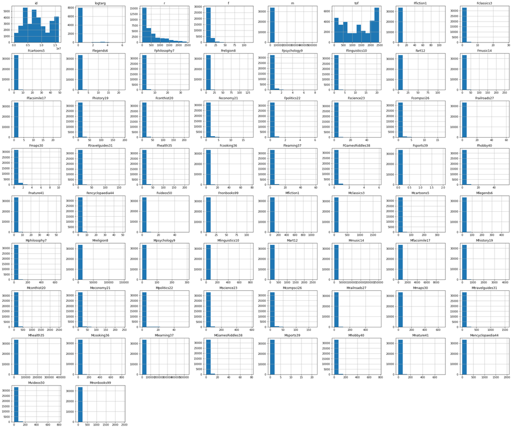

```python
fig = plt.figure(figsize=(35,30));
ax = fig.gca()
df.hist(ax=ax)
pass
```

```python
df_rn = df.rename(columns = {'r': 'Recency', 'f': 'Frequency', 'm': 'Monetary', 'tof': 'Time on File'})
df_rn
```

|  | id | logtarg | Recency | Frequency | Monetary | Time on File | Ffiction1 | Fclassics3 | Fcartoons5 | Flegends6 | Fphilosophy7 | Freligion8 | Fpsychology9 | Flinguistics10 | Fart12 | Fmusic14 | Ffacsimile17 | Fhistory19 | Fconthist20 | Feconomy21 | Fpolitics22 | Fscience23 | Fcompsci26 | Frailroads27 | Fmaps30 | Ftravelguides31 | Fhealth35 | Fcooking36 | Flearning37 | … |
| --- | --- | --- | --- | --- | --- | --- | --- | --- | --- | --- | --- | --- | --- | --- | --- | --- | --- | --- | --- | --- | --- | --- | --- | --- | --- | --- | --- | --- | --- | --- |
| 0 | 914 | NaN | 194 | 7 | 318.894775 | 1703 | 1 | 0 | 1 | 0 | 0 | 0 | 0 | 0 | 1 | 7 | 0 | 0 | 17 | 0 | 0 | 0 | 0 | 0 | 0 | 2 | 2 | 1 | 0 | … |
| 1 | 957 | NaN | 3 | 14 | 368.052246 | 2364 | 1 | 0 | 2 | 0 | 0 | 0 | 0 | 0 | 0 | 4 | 0 | 4 | 4 | 0 | 0 | 0 | 1 | 0 | 0 | 0 | 7 | 0 | 4 | … |
| 2 | 1406 | NaN | 1489 | 15 | 423.298340 | 2371 | 0 | 0 | 0 | 0 | 0 | 0 | 0 | 0 | 0 | 0 | 0 | 1 | 34 | 0 | 0 | 0 | 0 | 0 | 0 | 0 | 0 | 0 | 0 | … |
| 3 | 1414 | NaN | 155 | 4 | 71.217041 | 1290 | 0 | 0 | 0 | 0 | 0 | 0 | 0 | 0 | 0 | 0 | 0 | 0 | 7 | 0 | 0 | 0 | 0 | 0 | 0 | 0 | 0 | 0 | 0 | … |
| 4 | 1546 | NaN | 194 | 6 | 442.638184 | 2188 | 0 | 0 | 1 | 0 | 3 | 1 | 0 | 1 | 1 | 3 | 0 | 6 | 7 | 1 | 0 | 2 | 0 | 2 | 0 | 1 | 3 | 0 | 2 | … |
| ... | ... | ... | ... | ... | ... | ... | ... | ... | ... | ... | ... | ... | ... | ... | ... | ... | ... | ... | ... | ... | ... | ... | ... | ... | ... | ... | ... | ... | ... | … |
| 33708 | 16061594 | 2.635479 | 6 | 1 | 0.000000 | 6 | 0 | 0 | 0 | 0 | 0 | 0 | 0 | 0 | 0 | 0 | 0 | 0 | 0 | 0 | 0 | 0 | 0 | 0 | 0 | 0 | 0 | 0 | 0 | … |
| 33709 | 16062701 | 0.000000 | 4 | 1 | 0.000000 | 4 | 0 | 0 | 0 | 0 | 0 | 0 | 0 | 0 | 0 | 0 | 0 | 0 | 0 | 0 | 0 | 0 | 0 | 0 | 0 | 0 | 0 | 0 | 0 | … |
| 33710 | 16062981 | 0.000000 | 5 | 1 | 22.949997 | 5 | 0 | 0 | 3 | 0 | 0 | 0 | 0 | 0 | 0 | 0 | 0 | 0 | 0 | 0 | 0 | 0 | 0 | 0 | 0 | 0 | 0 | 0 | 0 | … |
| 33711 | 16063490 | 0.000000 | 0 | 0 | 0.000000 | 0 | 0 | 0 | 0 | 0 | 0 | 0 | 0 | 0 | 0 | 0 | 0 | 0 | 0 | 0 | 0 | 0 | 0 | 0 | 0 | 0 | 0 | 0 | 0 | … |
| 33712 | 16252071 | 0.000000 | 2 | 1 | 4.949997 | 2 | 0 | 0 | 0 | 0 | 0 | 0 | 0 | 0 | 0 | 0 | 0 | 0 | 0 | 0 | 0 | 0 | 0 | 0 | 0 | 0 | 1 | 0 | 0 | … |

33713 rows × 66 columns

```python
df_rmf = df_rn[['id','Recency','Frequency','Monetary']]
df_rmf
```

|  | id | Recency | Frequency | Monetary |
| --- | --- | --- | --- | --- |
| 0 | 914 | 194 | 7 | 318.894775 |
| 1 | 957 | 3 | 14 | 368.052246 |
| 2 | 1406 | 1489 | 15 | 423.298340 |
| 3 | 1414 | 155 | 4 | 71.217041 |
| 4 | 1546 | 194 | 6 | 442.638184 |
| ... | ... | ... | ... | ... |
| 33708 | 16061594 | 6 | 1 | 0.000000 |
| 33709 | 16062701 | 4 | 1 | 0.000000 |
| 33710 | 16062981 | 5 | 1 | 22.949997 |
| 33711 | 16063490 | 0 | 0 | 0.000000 |
| 33712 | 16252071 | 2 | 1 | 4.949997 |

33713 rows × 4 columns

```python
#remove customer with 0 values in Recency, Frequency, and Monetary
df_rmf1 = df_rmf[(df_rmf[['Recency','Frequency','Monetary']]!=0).any(axis=1)]
df_rmf1
```

|  | id | Recency | Frequency | Monetary |
| --- | --- | --- | --- | --- |
| 0 | 914 | 194 | 7 | 318.894775 |
| 1 | 957 | 3 | 14 | 368.052246 |
| 2 | 1406 | 1489 | 15 | 423.298340 |
| 3 | 1414 | 155 | 4 | 71.217041 |
| 4 | 1546 | 194 | 6 | 442.638184 |
| ... | ... | ... | ... | ... |
| 33707 | 16061233 | 6 | 1 | 34.849976 |
| 33708 | 16061594 | 6 | 1 | 0.000000 |
| 33709 | 16062701 | 4 | 1 | 0.000000 |
| 33710 | 16062981 | 5 | 1 | 22.949997 |
| 33712 | 16252071 | 2 | 1 | 4.949997 |

33355 rows × 4 columns

```python
df_rmf1.describe()
```

|  | id | Recency | Frequency | Monetary |
| --- | --- | --- | --- | --- |
| count | 3.335500e+04 | 33355.000000 | 33355.000000 | 33355.000000 |
| mean | 8.207836e+06 | 513.884215 | 5.883076 | 254.628235 |
| std | 4.420609e+06 | 542.766117 | 7.019427 | 3950.877048 |
| min | 9.140000e+02 | 1.000000 | 1.000000 | 0.000000 |
| 25% | 4.382374e+06 | 124.000000 | 2.000000 | 41.447250 |
| 50% | 7.958528e+06 | 299.000000 | 3.000000 | 104.379211 |
| 75% | 1.198238e+07 | 725.000000 | 7.000000 | 249.839966 |
| max | 1.625264e+07 | 2460.000000 | 118.000000 | 532892.000000 |

```python
cor = df_rmf1.corr()
cor
```

|  | id | Recency | Frequency | Monetary |
| --- | --- | --- | --- | --- |
| id | 1.000000 | -0.308582 | -0.336296 | -0.024689 |
| Recency | -0.308582 | 1.000000 | -0.252130 | -0.022316 |
| Frequency | -0.336296 | -0.252130 | 1.000000 | 0.080020 |
| Monetary | -0.024689 | -0.022316 | 0.080020 | 1.000000 |

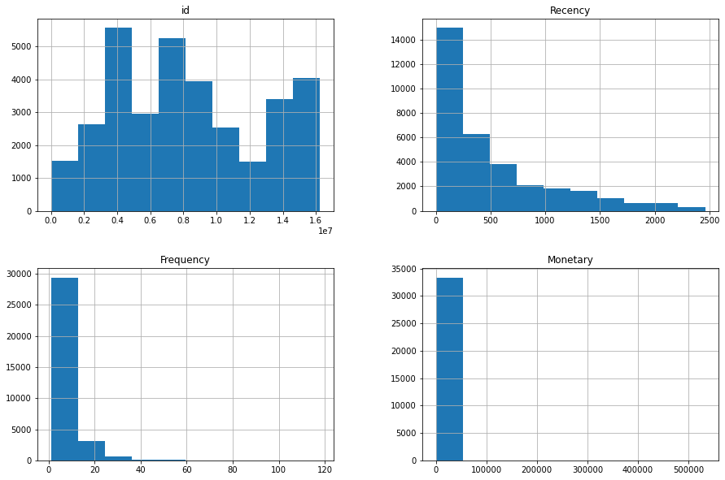

```python
fig = plt.figure(figsize=(15,10));
ax = fig.gca()
df_rmf1.hist(ax=ax)
pass
```

### 6. Choose either a “supervised” or an “unsupervised” approach to segment/cluster current customers using the data provided.

### Customer Segments with RFM Model

The simplest way to create customers segments from RFM Model is to use Quartiles. We assign a score from 1 to 4 to Recency, Frequency and Monetary. Four is the best/highest value, and one is the lowest/worst value. A final RFM score is calculated simply by combining individual RFM score numbers.

Reference: https://www.kaggle.com/code/sarahm/customer-segmentation-using-rfm-analysis/notebook

```python
#df_rmf2 = df_rmf1.drop(columns = ['id'])
quantiles = df_rmf1.quantile([0.25,0.5,0.75])
quantiles
```

|  | id | Recency | Frequency | Monetary |
| --- | --- | --- | --- | --- |
| 0.25 | 4382374.5 | 124.0 | 2.0 | 41.447250 |
| 0.50 | 7958528.0 | 299.0 | 3.0 | 104.379211 |
| 0.75 | 11982377.0 | 725.0 | 7.0 | 249.839966 |

```python
quantiles.to_dict()
```

```
{'id': {0.25: 4382374.5, 0.5: 7958528.0, 0.75: 11982377.0},
 'Recency': {0.25: 124.0, 0.5: 299.0, 0.75: 725.0},
 'Frequency': {0.25: 2.0, 0.5: 3.0, 0.75: 7.0},
 'Monetary': {0.25: 41.447250366, 0.5: 104.37921143, 0.75: 249.83996581999997}}
```

### Creation of RFM Segments

We will create two segmentation classes since, high recency is bad, while high frequency and monetary value is good.

```python
# Arguments (x = value, p = recency, monetary_value, frequency, d = quartiles dict)
def RScore(x,p,d):
    if x <= d[p][0.25]:
        return 4
    elif x <= d[p][0.50]:
        return 3
    elif x <= d[p][0.75]:
        return 2
    else:
        return 1
# Arguments (x = value, p = recency, monetary_value, frequency, k = quartiles dict)
def FMScore(x,p,d):
    if x <= d[p][0.25]:
        return 1
    elif x <= d[p][0.50]:
        return 2
    elif x <= d[p][0.75]:
        return 3
    else:
        return 4
```

```python
#create rfm segmentation table
rfm_segmentation = df_rmf1
rfm_segmentation['R_Quartile'] = rfm_segmentation['Recency'].apply(RScore, args=('Recency',quantiles,))
rfm_segmentation['F_Quartile'] = rfm_segmentation['Frequency'].apply(FMScore, args=('Frequency',quantiles,))
rfm_segmentation['M_Quartile'] = rfm_segmentation['Monetary'].apply(FMScore, args=('Monetary',quantiles,))
```

```python
rfm_segmentation
```

|  | id | Recency | Frequency | Monetary | R_Quartile | F_Quartile | M_Quartile |
| --- | --- | --- | --- | --- | --- | --- | --- |
| 0 | 914 | 194 | 7 | 318.894775 | 3 | 3 | 4 |
| 1 | 957 | 3 | 14 | 368.052246 | 4 | 4 | 4 |
| 2 | 1406 | 1489 | 15 | 423.298340 | 1 | 4 | 4 |
| 3 | 1414 | 155 | 4 | 71.217041 | 3 | 3 | 2 |
| 4 | 1546 | 194 | 6 | 442.638184 | 3 | 3 | 4 |
| ... | ... | ... | ... | ... | ... | ... | ... |
| 33707 | 16061233 | 6 | 1 | 34.849976 | 4 | 1 | 1 |
| 33708 | 16061594 | 6 | 1 | 0.000000 | 4 | 1 | 1 |
| 33709 | 16062701 | 4 | 1 | 0.000000 | 4 | 1 | 1 |
| 33710 | 16062981 | 5 | 1 | 22.949997 | 4 | 1 | 1 |
| 33712 | 16252071 | 2 | 1 | 4.949997 | 4 | 1 | 1 |

33355 rows × 7 columns

Now that we have the score of each customer, we can represent our customer segmentation. First, we need to combine the scores (R_Quartile, F_Quartile,M_Quartile) together.

```python
rfm_segmentation['RFMScore'] = rfm_segmentation.R_Quartile.map(str) \
                            + rfm_segmentation.F_Quartile.map(str) \
                            + rfm_segmentation.M_Quartile.map(str)
rfm_segmentation
```

|  | id | Recency | Frequency | Monetary | R_Quartile | F_Quartile | M_Quartile | RFMScore |
| --- | --- | --- | --- | --- | --- | --- | --- | --- |
| 0 | 914 | 194 | 7 | 318.894775 | 3 | 3 | 4 | 334 |
| 1 | 957 | 3 | 14 | 368.052246 | 4 | 4 | 4 | 444 |
| 2 | 1406 | 1489 | 15 | 423.298340 | 1 | 4 | 4 | 144 |
| 3 | 1414 | 155 | 4 | 71.217041 | 3 | 3 | 2 | 332 |
| 4 | 1546 | 194 | 6 | 442.638184 | 3 | 3 | 4 | 334 |
| ... | ... | ... | ... | ... | ... | ... | ... | ... |
| 33707 | 16061233 | 6 | 1 | 34.849976 | 4 | 1 | 1 | 411 |
| 33708 | 16061594 | 6 | 1 | 0.000000 | 4 | 1 | 1 | 411 |
| 33709 | 16062701 | 4 | 1 | 0.000000 | 4 | 1 | 1 | 411 |
| 33710 | 16062981 | 5 | 1 | 22.949997 | 4 | 1 | 1 | 411 |
| 33712 | 16252071 | 2 | 1 | 4.949997 | 4 | 1 | 1 | 411 |

33355 rows × 8 columns

Best Recency score = 4: most recently purchase. Best Frequency score = 4: most quantity purchase. Best Monetary score = 4: spent the most.

```python
#find the best customers
rfm_segmentation[rfm_segmentation['RFMScore']=='444'].sort_values('Monetary', ascending=False)
```

|  | id | Recency | Frequency | Monetary | R_Quartile | F_Quartile | M_Quartile | RFMScore |
| --- | --- | --- | --- | --- | --- | --- | --- | --- |
| 9044 | 5900190 | 69 | 11 | 532892.000000 | 4 | 4 | 4 | 444 |
| 13833 | 8192553 | 23 | 31 | 147684.875000 | 4 | 4 | 4 | 444 |
| 21167 | 13729756 | 16 | 118 | 18582.531250 | 4 | 4 | 4 | 444 |
| 7478 | 4980476 | 25 | 38 | 10073.937500 | 4 | 4 | 4 | 444 |
| 2538 | 2901870 | 34 | 110 | 9446.015625 | 4 | 4 | 4 | 444 |
| ... | ... | ... | ... | ... | ... | ... | ... | ... |
| 14920 | 8697604 | 19 | 16 | 250.204346 | 4 | 4 | 4 | 444 |
| 2169 | 2704269 | 89 | 8 | 250.178467 | 4 | 4 | 4 | 444 |
| 21691 | 13870700 | 33 | 10 | 250.110352 | 4 | 4 | 4 | 444 |
| 30716 | 9244913 | 61 | 12 | 249.959595 | 4 | 4 | 4 | 444 |
| 12494 | 7941730 | 47 | 8 | 249.850464 | 4 | 4 | 4 | 444 |

2734 rows × 8 columns

### Segmenting Customers

```python
#Calcuate the number of cusomters in each segment:
print("Best Customers: ",len(rfm_segmentation[rfm_segmentation['RFMScore']=='444']))
print('Loyal Customers: ',len(rfm_segmentation[rfm_segmentation['F_Quartile']==4]))
print("Big Spenders: ",len(rfm_segmentation[rfm_segmentation['M_Quartile']==4]))
print('Almost Lost: ', len(rfm_segmentation[rfm_segmentation['RFMScore']=='244']))
print('Lost Customers: ',len(rfm_segmentation[rfm_segmentation['RFMScore']=='144']))
print('Lost Cheap Customers: ',len(rfm_segmentation[rfm_segmentation['RFMScore']=='111']))
```

```
Best Customers:  2734
Loyal Customers:  8282
Big Spenders:  8339
Almost Lost:  1366
Lost Customers:  553
Lost Cheap Customers:  2194
```

Now we have different segements of customers and we can find approriate methods to target each segment.

Here are some examples:

- **Best Customers**: They will be the first group of people getting notified with new products and have early access to new products.
- **Loyal Customers**: Frequent customers might receive a most popular suggestion from the same category of book as their current purchase without a discount.
- **Lost Cheap Customers**: Infrequent customers might receive a discounted popular item to incentivize a purchase.

### Create sample data (5-10 records) with synthetic data to show how a new transaction will be scored and assigned to a segment/cluster.

```python
data = {'id':[1,2,3,4,5,6,7,8,9,10],
        'Recency':[20, 21, 19, 18, 12, 24, 48, 64, 56, 78],
        'Frequency':[128, 46, 100, 57, 69, 91, 21, 19, 47, 96],
        'Monetary':[2468, 135, 77, 128, 3102, 2577, 408, 124, 99, 55]}

df = pd.DataFrame(data)
df
```

|  | id | Recency | Frequency | Monetary |
| --- | --- | --- | --- | --- |
| 0 | 1 | 20 | 128 | 2468 |
| 1 | 2 | 21 | 46 | 135 |
| 2 | 3 | 19 | 100 | 77 |
| 3 | 4 | 18 | 57 | 128 |
| 4 | 5 | 12 | 69 | 3102 |
| 5 | 6 | 24 | 91 | 2577 |
| 6 | 7 | 48 | 21 | 408 |
| 7 | 8 | 64 | 19 | 124 |
| 8 | 9 | 56 | 47 | 99 |
| 9 | 10 | 78 | 96 | 55 |

```python
quantiles_df = df.quantile([0.25,0.5,0.75])
quantiles_df
```

|  | id | Recency | Frequency | Monetary |
| --- | --- | --- | --- | --- |
| 0.25 | 3.25 | 19.25 | 46.25 | 105.25 |
| 0.50 | 5.50 | 22.50 | 63.00 | 131.50 |
| 0.75 | 7.75 | 54.00 | 94.75 | 1953.00 |

```python
quantiles_df.to_dict()
```

```
{'id': {0.25: 3.25, 0.5: 5.5, 0.75: 7.75},
 'Recency': {0.25: 19.25, 0.5: 22.5, 0.75: 54.0},
 'Frequency': {0.25: 46.25, 0.5: 63.0, 0.75: 94.75},
 'Monetary': {0.25: 105.25, 0.5: 131.5, 0.75: 1953.0}}
```

```python
rfm_segmentation_df = df
rfm_segmentation_df['R_Quartile'] = rfm_segmentation_df['Recency'].apply(RScore, args=('Recency',quantiles_df,))
rfm_segmentation_df['F_Quartile'] = rfm_segmentation_df['Frequency'].apply(FMScore, args=('Frequency',quantiles_df,))
rfm_segmentation_df['M_Quartile'] = rfm_segmentation_df['Monetary'].apply(FMScore, args=('Monetary',quantiles_df,))
```

```python
rfm_segmentation_df['RFMScore'] = rfm_segmentation_df.R_Quartile.map(str) \
                            + rfm_segmentation_df.F_Quartile.map(str) \
                            + rfm_segmentation_df.M_Quartile.map(str)
rfm_segmentation_df
```

|  | id | Recency | Frequency | Monetary | R_Quartile | F_Quartile | M_Quartile | RFMScore |
| --- | --- | --- | --- | --- | --- | --- | --- | --- |
| 0 | 1 | 20 | 128 | 2468 | 3 | 4 | 4 | 344 |
| 1 | 2 | 21 | 46 | 135 | 3 | 1 | 3 | 313 |
| 2 | 3 | 19 | 100 | 77 | 4 | 4 | 1 | 441 |
| 3 | 4 | 18 | 57 | 128 | 4 | 2 | 2 | 422 |
| 4 | 5 | 12 | 69 | 3102 | 4 | 3 | 4 | 434 |
| 5 | 6 | 24 | 91 | 2577 | 2 | 3 | 4 | 234 |
| 6 | 7 | 48 | 21 | 408 | 2 | 1 | 3 | 213 |
| 7 | 8 | 64 | 19 | 124 | 1 | 1 | 2 | 112 |
| 8 | 9 | 56 | 47 | 99 | 1 | 2 | 1 | 121 |
| 9 | 10 | 78 | 96 | 55 | 1 | 4 | 1 | 141 |

```python
rfm_segmentation_df.sort_values('Monetary', ascending=False)
```

|  | id | Recency | Frequency | Monetary | R_Quartile | F_Quartile | M_Quartile | RFMScore |
| --- | --- | --- | --- | --- | --- | --- | --- | --- |
| 4 | 5 | 12 | 69 | 3102 | 4 | 3 | 4 | 434 |
| 5 | 6 | 24 | 91 | 2577 | 2 | 3 | 4 | 234 |
| 0 | 1 | 20 | 128 | 2468 | 3 | 4 | 4 | 344 |
| 6 | 7 | 48 | 21 | 408 | 2 | 1 | 3 | 213 |
| 1 | 2 | 21 | 46 | 135 | 3 | 1 | 3 | 313 |
| 3 | 4 | 18 | 57 | 128 | 4 | 2 | 2 | 422 |
| 7 | 8 | 64 | 19 | 124 | 1 | 1 | 2 | 112 |
| 8 | 9 | 56 | 47 | 99 | 1 | 2 | 1 | 121 |
| 2 | 3 | 19 | 100 | 77 | 4 | 4 | 1 | 441 |
| 9 | 10 | 78 | 96 | 55 | 1 | 4 | 1 | 141 |

```python
print("Best Customers: ",len(rfm_segmentation_df[rfm_segmentation_df['RFMScore']=='434']))
print('Loyal Customers: ',len(rfm_segmentation_df[rfm_segmentation_df['F_Quartile']==4]))
print("Big Spenders: ",len(rfm_segmentation_df[rfm_segmentation_df['M_Quartile']==4]))
print('Almost Lost: ', len(rfm_segmentation_df[rfm_segmentation_df['RFMScore']=='244']))
print('Lost Customers: ',len(rfm_segmentation_df[rfm_segmentation_df['RFMScore']=='121']))
print('Lost Cheap Customers: ',len(rfm_segmentation_df[rfm_segmentation_df['RFMScore']=='141']))
```

```
Best Customers:  1
Loyal Customers:  3
Big Spenders:  3
Almost Lost:  0
Lost Customers:  1
Lost Cheap Customers:  1
```

```python
rfm_segmentation_df['Segmentation'] = 0

rfm_segmentation_df['Segmentation'][rfm_segmentation_df['F_Quartile']==4] = 'Loyal Customers'
rfm_segmentation_df['Segmentation'][rfm_segmentation_df['M_Quartile']==4] = 'Big Spenders'
rfm_segmentation_df['Segmentation'][rfm_segmentation_df['RFMScore']=='434'] = 'Best Customers'

rfm_segmentation_df['Segmentation'][rfm_segmentation_df['RFMScore']=='244'] = 'Almost Lost'
rfm_segmentation_df['Segmentation'][rfm_segmentation_df['RFMScore']=='121'] = 'Lost Customers'
rfm_segmentation_df['Segmentation'][rfm_segmentation_df['RFMScore']=='141'] = 'Lost Cheap Customers'
```

```python
rfm_segmentation_df
```

|  | id | Recency | Frequency | Monetary | R_Quartile | F_Quartile | M_Quartile | RFMScore | Segmentation |
| --- | --- | --- | --- | --- | --- | --- | --- | --- | --- |
| 0 | 1 | 20 | 128 | 2468 | 3 | 4 | 4 | 344 | Big Spenders |
| 1 | 2 | 21 | 46 | 135 | 3 | 1 | 3 | 313 | 0 |
| 2 | 3 | 19 | 100 | 77 | 4 | 4 | 1 | 441 | Loyal Customers |
| 3 | 4 | 18 | 57 | 128 | 4 | 2 | 2 | 422 | 0 |
| 4 | 5 | 12 | 69 | 3102 | 4 | 3 | 4 | 434 | Best Customers |
| 5 | 6 | 24 | 91 | 2577 | 2 | 3 | 4 | 234 | Big Spenders |
| 6 | 7 | 48 | 21 | 408 | 2 | 1 | 3 | 213 | 0 |
| 7 | 8 | 64 | 19 | 124 | 1 | 1 | 2 | 112 | 0 |
| 8 | 9 | 56 | 47 | 99 | 1 | 2 | 1 | 121 | Lost Customers |
| 9 | 10 | 78 | 96 | 55 | 1 | 4 | 1 | 141 | Lost Cheap Customers |